# Beautiful thematic maps with ggplot2

Timo Grossenbacher

December 25, 2016

# Beautiful thematic maps with ggplot2 (only)

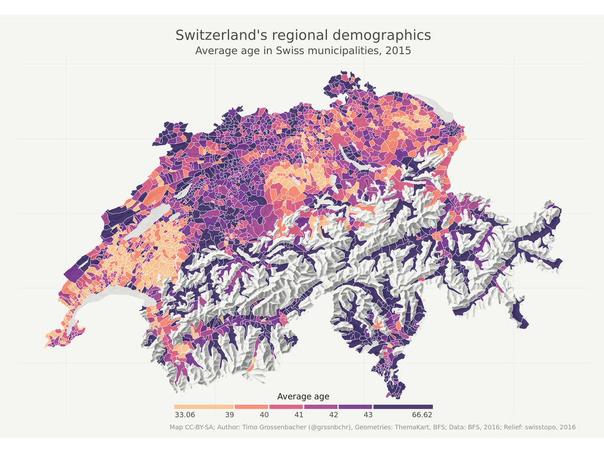

The above *choropleth* was created with `ggplot2` (2.2.0) only. Well, almost. Of course, you need the usual suspects such as `rgdal` and `rgeos` when dealing with geodata, and `raster` for the relief. But apart from that: nothing fancy such as `ggmap` or the like. The imported packages are kept to an absolute minimum.

In this blog post, I am going to explain step by step how I (eventually) achieved this result – from a very basic, useless, ugly, default map to the publication-ready and (in my opinion) highly aesthetic choropleth.

## Reproducibility

As always, you can reproduce, reuse and remix everything you find here, just go to [this repository](https://github.com/grssnbchr/thematic-maps-ggplot2) and clone it. All the needed input files are in the `input` folder, and the main file to execute is `index.Rmd`. Right now, knitting it produces an `index.md` that I use for my blog post on timogrossenbacher.ch, but you can adapt the script to produce an HTML file, too. The PNGs produced herein are saved to `wp-content/uploads/2016/12` so I can display them directly in my blog, but of course you can also adjust this.

## Preparations

### Clear workspace and install necessary packages

This is just my usual routine: Detach all packages, remove all variables in the global environment, etc, and then load the packages. Saves me a lot of headaches.

```r
knitr::opts_chunk$set(
    out.width = "100%",
    dpi = 300,
    fig.width = 8,
    fig.height = 6,
    fig.path = 'https://timogrossenbacher.ch/wp-content/uploads/2016/12/tm-',
    strip.white = T,
    dev = "png",
    dev.args = list(png = list(bg = "transparent"))
)

remove(list = ls(all.names = TRUE))

detachAllPackages <- function() {
  basic.packages.blank <-  c("stats",
                             "graphics",
                             "grDevices",
                             "utils",
                             "datasets",
                             "methods",
                             "base")
  basic.packages <- paste("package:", basic.packages.blank, sep = "")

  package.list <- search()[ifelse(unlist(gregexpr("package:", search())) == 1,
                                  TRUE,
                                  FALSE)]

  package.list <- setdiff(package.list, basic.packages)

  if (length(package.list) > 0)  for (package in package.list) {
    detach(package, character.only = TRUE)
    print(paste("package ", package, " detached", sep = ""))
  }
}

detachAllPackages()


if (!require(rgeos)) {
  install.packages("rgeos", repos = "http://cran.us.r-project.org")
  require(rgeos)
}
if (!require(rgdal)) {
  install.packages("rgdal", repos = "http://cran.us.r-project.org")
  require(rgdal)
}
if (!require(raster)) {
  install.packages("raster", repos = "http://cran.us.r-project.org")
  require(raster)
}
if(!require(ggplot2)) {
  install.packages("ggplot2", repos="http://cloud.r-project.org")
  require(ggplot2)
}
if(!require(viridis)) {
  install.packages("viridis", repos="http://cloud.r-project.org")
  require(viridis)
}
if(!require(dplyr)) {
  install.packages("dplyr", repos = "https://cloud.r-project.org/")
  require(dplyr)
}
if(!require(gtable)) {
  install.packages("gtable", repos = "https://cloud.r-project.org/")
  require(gtable)
}
if(!require(grid)) {
  install.packages("grid", repos = "https://cloud.r-project.org/")
  require(grid)
}
if(!require(readxl)) {
  install.packages("readxl", repos = "https://cloud.r-project.org/")
  require(readxl)
}
if(!require(magrittr)) {
  install.packages("magrittr", repos = "https://cloud.r-project.org/")
  require(magrittr)
}
```

### General ggplot2 theme for map

First of all, I define a generic theme that will be used as the basis for all of the following steps. It’s based on `theme_minimal` and basically resets all the axes. It also defined a very subtle grid and a warmgrey background, which gives it some sort of paper map feeling, I find.

The font used here is `Ubuntu Regular` – adapt to your liking, but the font must be installed on your OS.

```r
theme_map <- function(...) {
  theme_minimal() +
  theme(
    text = element_text(family = "Ubuntu Regular", color = "#22211d"),
    axis.line = element_blank(),
    axis.text.x = element_blank(),
    axis.text.y = element_blank(),
    axis.ticks = element_blank(),
    axis.title.x = element_blank(),
    axis.title.y = element_blank(),
    # panel.grid.minor = element_line(color = "#ebebe5", size = 0.2),
    panel.grid.major = element_line(color = "#ebebe5", size = 0.2),
    panel.grid.minor = element_blank(),
    plot.background = element_rect(fill = "#f5f5f2", color = NA),
    panel.background = element_rect(fill = "#f5f5f2", color = NA),
    legend.background = element_rect(fill = "#f5f5f2", color = NA),
    panel.border = element_blank(),
    ...
  )
}
```

## Data sources

For this choropleth, I used **three** data sources:

- Thematic data: Average age per municipality as of end of 2015. The data is freely available from [The Swiss Federal Statistical Office (FSO)](https://www.bfs.admin.ch/bfs/de/home/statistiken/bevoelkerung/stand-entwicklung/alter-zivilstand-staatsangehoerigkeit.html) and included in the `input` folder.
- Municipality geometries: The geometries do not show the political borders of Swiss municipalities, but the so-called “productive” area, i.e., larger lakes and other “unproductive” areas such as mountains are excluded. This has two advantages: 1) The relatively sparsely populated but very large municipalities in the Alps don’t have too much visual weight and 2) it allows us to use the beautiful raster relief of the Alps as a background. The data are also from the FSO, but not freely available. You could also use the freely available [political boundaries](https://www.bfs.admin.ch/bfs/de/home/dienstleistungen/geostat/geodaten-bundesstatistik/administrative-grenzen/generalisierte-gemeindegrenzen.html) of course. I was allowed to republish the Shapefile for this educational purpose (also included in the `input` folder). Please stick to that policy.
- Relief: This is a freely available GeoTIFF from [The Swiss Federal Office of Topography (swisstopo)](https://shop.swisstopo.admin.ch/en/products/maps/national/digital/srm1000).

### Read in data and preprocess

```r
data <- read.csv("https://github.com/grssnbchr/thematic-maps-ggplot2/blob/master/input/avg_age_15.csv", stringsAsFactors = F)
```

### Read in geodata

Here, the geodata is loaded using `rgeos` / `rgdal` standard procedures. It is then *“fortified”*, i.e. transformed into a ggplot2-compatible data frame (the `fortify`-function is part of `ggplot2`). Also, the thematic data is joined using the `bfs_id` field (each municipality has a unique one).

```r
gde_15 <- readOGR("https://github.com/grssnbchr/thematic-maps-ggplot2/blob/master/input/geodata/gde-1-1-15.shp", layer = "gde-1-1-15")
# set crs to ch1903/lv03, just to make sure  (EPSG:21781)
crs(gde_15) <- "+proj=somerc +lat_0=46.95240555555556
+lon_0=7.439583333333333 +k_0=1 +x_0=600000 +y_0=200000
+ellps=bessel +towgs84=674.374,15.056,405.346,0,0,0,0 +units=m +no_defs"
# fortify, i.e., make ggplot2-compatible
map_data_fortified <- fortify(gde_15, region = "BFS_ID") %>%
  mutate(id = as.numeric(id))
# now we join the thematic data
map_data <- map_data_fortified %>% left_join(data, by = c("id" = "bfs_id"))

# whole municipalities
gde_15_political <- readOGR("input/geodata/g1g15.shp", layer = "g1g15")
crs(gde_15_political) <- "+proj=somerc +lat_0=46.95240555555556
+lon_0=7.439583333333333 +k_0=1 +x_0=600000 +y_0=200000
+ellps=bessel +towgs84=674.374,15.056,405.346,0,0,0,0 +units=m +no_defs"
map_data_political_fortified <- fortify(gde_15_political, region = "GMDNR") %>%
  mutate(id = as.numeric(id))
map_data_political <- map_data_political_fortified %>% left_join(data, by = c("id" = "bfs_id"))
map_data_political <- map_data_political[complete.cases(map_data_political),]
# read in background relief
relief <- raster("input/geodata/02-relief-georef-clipped-resampled.tif")
relief_spdf <- as(relief, "SpatialPixelsDataFrame")
# relief is converted to a very simple data frame,
# just as the fortified municipalities.
# for that we need to convert it to a
# SpatialPixelsDataFrame first, and then extract its contents
# using as.data.frame
relief <- as.data.frame(relief_spdf) %>%
  rename(value = `X02.relief.georef.clipped.resampled`)
# remove unnecessary variables
rm(relief_spdf)
rm(gde_15)
rm(map_data_fortified)
rm(map_data_political_fortified)
```

## A very basic map

What follows now is a very basic map with the municipalities rendered with `geom_polygon` and their outline with `geom_path`. I don’t even define a color scale here, it just uses ggplot2’s default continuous color scale, because `avg_age_15` is a continuous variable.

Because the geodata are in a projected format, it is important to use `coord_equal()` here, if not, Switzerland would be distorted.

```r
p <- ggplot() +
    # municipality polygons
    geom_polygon(data = map_data, aes(fill = avg_age_15,
                                      x = long,
                                      y = lat,
                                      group = group)) +
    # municipality outline
    geom_path(data = map_data, aes(x = long,
                                   y = lat,
                                   group = group),
              color = "white", size = 0.1) +
    coord_equal() +
    # add the previously defined basic theme
    theme_map() +
    labs(x = NULL,
         y = NULL,
         title = "Switzerland's regional demographics",
         subtitle = "Average age in Swiss municipalities, 2015",
         caption = "Geometries: ThemaKart, BFS; Data: BFS, 2016")
p
```

### A better color scale

```r
q <- p + scale_fill_viridis(option = "magma", direction = -1)
q
```

### Horizontal legend

Also I think one could save some space by using a horizontal legend at the bottom of the plot.

```r
q <- p +
  # this is the main part
  theme(legend.position = "bottom") +
  scale_fill_viridis(
    option = "magma",
    direction = -1,
    name = "Average age",
    # here we use guide_colourbar because it is still a continuous scale
    guide = guide_colorbar(
      direction = "horizontal",
      barheight = unit(2, units = "mm"),
      barwidth = unit(50, units = "mm"),
      draw.ulim = F,
      title.position = 'top',
      # some shifting around
      title.hjust = 0.5,
      label.hjust = 0.5
  ))
q
```

## Discrete classes with quantile scale

I am still not happy with the color scale because I think regional patterns could be made more clearly visible. For that I break up the continuous `avg_age_15` variable into 6 quantiles (remember your statistics class?). The effect of that is that I now have about the same number of municipalities in each class.

```r
no_classes <- 6
labels <- c()

quantiles <- quantile(map_data$avg_age_15,
                      probs = seq(0, 1, length.out = no_classes + 1))

# here I define custom labels (the default ones would be ugly)
labels <- c()
for(idx in 1:length(quantiles)){
  labels <- c(labels, paste0(round(quantiles[idx], 2),
                             " – ",
                             round(quantiles[idx + 1], 2)))
}
# I need to remove the last label
# because that would be something like "66.62 - NA"
labels <- labels[1:length(labels)-1]

# here I actually create a new
# variable on the dataset with the quantiles
map_data$avg_age_15_quantiles <- cut(map_data$avg_age_15,
                                     breaks = quantiles,
                                     labels = labels,
                                     include.lowest = T)

p <- ggplot() +
    # municipality polygons (watch how I
   # use the new variable for the fill aesthetic)
    geom_polygon(data = map_data, aes(fill = avg_age_15_quantiles,
                                      x = long,
                                      y = lat,
                                      group = group)) +
    # municipality outline
    geom_path(data = map_data, aes(x = long,
                                   y = lat,
                                   group = group),
              color = "white", size = 0.1) +
    coord_equal() +
    theme_map() +
    labs(x = NULL,
         y = NULL,
         title = "Switzerland's regional demographics",
         subtitle = "Average age in Swiss municipalities, 2015",
         caption = "Geometries: ThemaKart, BFS; Data: BFS, 2016") +
  # now the discrete-option is used,
  # and we use guide_legend instead of guide_colourbar
  scale_fill_viridis(
    option = "magma",
    name = "Average age",
    discrete = T,
    direction = -1,
    guide = guide_legend(
     keyheight = unit(5, units = "mm"),
     title.position = 'top',
     reverse = T
  ))
p
```

### Discrete classes with pretty breaks

```r
# here I define equally spaced pretty breaks -
# they will be surrounded by the minimum value at
# the beginning and the maximum value at the end.
# One could also use something like c(39,39.5,41,42.5,43),
# this totally depends on the data and your personal taste.
pretty_breaks <- c(39,40,41,42,43)
# find the extremes
minVal <- min(map_data$avg_age_15, na.rm = T)
maxVal <- max(map_data$avg_age_15, na.rm = T)
# compute labels
labels <- c()
brks <- c(minVal, pretty_breaks, maxVal)
# round the labels (actually, only the extremes)
for(idx in 1:length(brks)){
  labels <- c(labels,round(brks[idx + 1], 2))
}

labels <- labels[1:length(labels)-1]
# define a new variable on the data set just as above
map_data$brks <- cut(map_data$avg_age_15,
                     breaks = brks,
                     include.lowest = TRUE,
                     labels = labels)

brks_scale <- levels(map_data$brks)
labels_scale <- rev(brks_scale)

p <- ggplot() +
    # municipality polygons
    geom_polygon(data = map_data, aes(fill = brks,
                                      x = long,
                                      y = lat,
                                      group = group)) +
    # municipality outline
    geom_path(data = map_data, aes(x = long,
                                   y = lat,
                                   group = group),
              color = "white", size = 0.1) +
    coord_equal() +
    theme_map() +
    theme(legend.position = "bottom") +
    labs(x = NULL,
         y = NULL,
         title = "Switzerland's regional demographics",
         subtitle = "Average age in Swiss municipalities, 2015",
         caption = "Geometries: ThemaKart, BFS; Data: BFS, 2016")
q <- p +
    # now we have to use a manual scale,
    # because only ever one number should be shown per label
    scale_fill_manual(
          # in manual scales, one has to define colors, well, manually
          # I can directly access them using viridis' magma-function
          values = rev(magma(6)),
          breaks = rev(brks_scale),
          name = "Average age",
          drop = FALSE,
          labels = labels_scale,
          guide = guide_legend(
            direction = "horizontal",
            keyheight = unit(2, units = "mm"),
            keywidth = unit(70 / length(labels), units = "mm"),
            title.position = 'top',
            # I shift the labels around, the should be placed
            # exactly at the right end of each legend key
            title.hjust = 0.5,
            label.hjust = 1,
            nrow = 1,
            byrow = T,
            # also the guide needs to be reversed
            reverse = T,
            label.position = "bottom"
          )
      )

q
```

Now we have classes with the ranges 33.06 to 39, 39 to 40, 40 to 41, and so on… So four classes are of the same size and the two classes with the extremes are differently sized. One option to communicate this is to make their respective legend keys wider than usual. `ggplot2` doesn’t have a standard option for that, so I had to dig deep into the underlying `grid` package and extract the relevant `grobs` and change their widths. All of the following numbers are the result of trying and trying around. I have not yet fully understood how that system actually works and certainly, it could be made more versatile. Something for next christmas…

### More intuitive legend

```r
extendLegendWithExtremes <- function(p){
  p_grob <- ggplotGrob(p)
  legend <- gtable_filter(p_grob, "guide-box")
  legend_grobs <- legend$grobs[[1]]$grobs[[1]]
  # grab the first key of legend
  legend_first_key <- gtable_filter(legend_grobs, "key-3-1-1")
  legend_first_key$widths <- unit(2, units = "cm")
  # modify its width and x properties to make it longer
  legend_first_key$grobs[[1]]$width <- unit(2, units = "cm")
  legend_first_key$grobs[[1]]$x <- unit(0.15, units = "cm")

  # last key of legend
  legend_last_key <- gtable_filter(legend_grobs, "key-3-6-1")
  legend_last_key$widths <- unit(2, units = "cm")
  # analogous
  legend_last_key$grobs[[1]]$width <- unit(2, units = "cm")
  legend_last_key$grobs[[1]]$x <- unit(1.02, units = "cm")

  # grab the last label so we can also shift its position
  legend_last_label <- gtable_filter(legend_grobs, "label-5-6")
  legend_last_label$grobs[[1]]$x <- unit(2, units = "cm")

  # Insert new color legend back into the combined legend
  legend_grobs$grobs[legend_grobs$layout$name == "key-3-1-1"][[1]] <-
    legend_first_key$grobs[[1]]
  legend_grobs$grobs[legend_grobs$layout$name == "key-3-6-1"][[1]] <-
    legend_last_key$grobs[[1]]
  legend_grobs$grobs[legend_grobs$layout$name == "label-5-6"][[1]] <-
    legend_last_label$grobs[[1]]

  # finally, I need to create a new label for the minimum value
  new_first_label <- legend_last_label$grobs[[1]]
  new_first_label$label <- round(min(map_data$avg_age_15, na.rm = T), 2)
  new_first_label$x <- unit(-0.15, units = "cm")
  new_first_label$hjust <- 1

  legend_grobs <- gtable_add_grob(legend_grobs,
                                  new_first_label,
                                  t = 6,
                                  l = 2,
                                  name = "label-5-0",
                                  clip = "off")
  legend$grobs[[1]]$grobs[1][[1]] <- legend_grobs
  p_grob$grobs[p_grob$layout$name == "guide-box"][[1]] <- legend

  # the plot is now drawn using this grid function
  grid.newpage()
  grid.draw(p_grob)
}
extendLegendWithExtremes(q)
```

### Better colors for classes

```r
p <- p + scale_fill_manual(
  # magma with 8 classes
  values = rev(magma(8)[2:7]),
  breaks = rev(brks_scale),
  name = "Average age",
  drop = FALSE,
  labels = labels_scale,
  guide = guide_legend(
    direction = "horizontal",
    keyheight = unit(2, units = "mm"),
    keywidth = unit(70/length(labels), units = "mm"),
    title.position = 'top',
    title.hjust = 0.5,
    label.hjust = 1,
    nrow = 1,
    byrow = T,
    reverse = T,
    label.position = "bottom"
  )
)
# reapply the legend modification from above
extendLegendWithExtremes(p)
```

## Relief

What’s needed now to give it a boost of aesthetic value is the relief of the Swiss Alps. Every mountain lover will appreciate that.

I add the relief with `geom_raster`. Now the problem is that I can’t use the `fill` aesthetic because it (or its scale) is already in use by the `geom_polygon` layer. The workaround is using the `alpha` aesthetic which works fine here because the relief should be displayed with a greyscale anyway.

```r
p <- ggplot() +
    # raster comes as the first layer, municipalities on top
    geom_raster(data = relief, aes(x = x,
                                  y = y,
                                  alpha = value)) +
    # use the "alpha hack"
    scale_alpha(name = "", range = c(0.6, 0), guide = F)  +
    # municipality polygons
    geom_polygon(data = map_data, aes(fill = brks,
                                      x = long,
                                      y = lat,
                                      group = group)) +
    # municipality outline
    geom_path(data = map_data, aes(x = long,
                                   y = lat,
                                   group = group),
              color = "white", size = 0.1) +
    # apart from that, nothing changes
    coord_equal() +
    theme_map() +
    theme(legend.position = "bottom") +
    labs(x = NULL,
         y = NULL,
         title = "Switzerland's regional demographics",
         subtitle = "Average age in Swiss municipalities, 2015",
         caption = "Geometries: ThemaKart, BFS; Data: BFS, 2016; Relief: swisstopo, 2016") +
    scale_fill_manual(
      values = rev(magma(8)[2:7]),
      breaks = rev(brks_scale),
      name = "Average age",
      drop = FALSE,
      labels = labels_scale,
      guide = guide_legend(
        direction = "horizontal",
        keyheight = unit(2, units = "mm"),
        keywidth = unit(70/length(labels), units = "mm"),
        title.position = 'top',
        title.hjust = 0.5,
        label.hjust = 1,
        nrow = 1,
        byrow = T,
        reverse = T,
        label.position = "bottom"
      )
    )
extendLegendWithExtremes(p)
```

## Final map

What follows are a couple of adjustments concerning:

- font colors
- the position of the title
- the plot margins, i.e.: how to make better use of the available space and show the map as big as possible
- smaller and less prominent caption at the bottom

Most of that happens in the additional `theme` specifications. Again, this is just tediously trying out values after values after values…

To my great joy I also discovered that there is an `alpha` argument to the `magma` function, which gives the colors a certain pastel tone and make the map look even more geo-hipsterish (if you ask me).

```r
p <- ggplot() +
    # municipality polygons
    geom_raster(data = relief, aes_string(x = "x",
                                          y = "y",
                                          alpha = "value")) +
    scale_alpha(name = "", range = c(0.6, 0), guide = F)  +
    geom_polygon(data = map_data, aes(fill = brks,
                                      x = long,
                                      y = lat,
                                      group = group)) +
    # municipality outline
    geom_path(data = map_data, aes(x = long,
                                   y = lat,
                                   group = group),
              color = "white", size = 0.1) +
    coord_equal() +
    theme_map() +
    theme(
      legend.position = c(0.5, 0.03),
      legend.text.align = 0,
      legend.background = element_rect(fill = alpha('white', 0.0)),
      legend.text = element_text(size = 7, hjust = 0, color = "#4e4d47"),
      plot.title = element_text(hjust = 0.5, color = "#4e4d47"),
      plot.subtitle = element_text(hjust = 0.5, color = "#4e4d47",
                                   margin = margin(b = -0.1,
                                                   t = -0.1,
                                                   l = 2,
                                                   unit = "cm"),
                                   debug = F),
      legend.title = element_text(size = 8),
      plot.margin = unit(c(.5,.5,.2,.5), "cm"),
      panel.spacing = unit(c(-.1,0.2,.2,0.2), "cm"),
      panel.border = element_blank(),
      plot.caption = element_text(size = 6,
                                  hjust = 0.92,
                                  margin = margin(t = 0.2,
                                                  b = 0,
                                                  unit = "cm"),
                                  color = "#939184")
    ) +
    labs(x = NULL,
         y = NULL,
         title = "Switzerland's regional demographics",
         subtitle = "Average age in Swiss municipalities, 2015",
         caption = "Map CC-BY-SA; Author: Timo Grossenbacher (@grssnbchr), Geometries: ThemaKart, BFS; Data: BFS, 2016; Relief: swisstopo, 2016") +
    scale_fill_manual(
      values = rev(magma(8, alpha = 0.8)[2:7]),
      breaks = rev(brks_scale),
      name = "Average age",
      drop = FALSE,
      labels = labels_scale,
      guide = guide_legend(
        direction = "horizontal",
        keyheight = unit(2, units = "mm"),
        keywidth = unit(70/length(labels), units = "mm"),
        title.position = 'top',
        title.hjust = 0.5,
        label.hjust = 1,
        nrow = 1,
        byrow = T,
        reverse = T,
        label.position = "bottom"
      )
    )
extendLegendWithExtremes(p)
```

Thanks for reading, I hope you learned something. Producing high-quality graphics like these with pure `ggplot2` is sometimes more an art than a science and veeeeeeeryyyyy tedious, and it would probably be way easier to export the map at an early stage and make adjustments in Illustrator or another vector editor. But then, I just like the thought of a fully automagic, reproducible workflow, it’s almost an obsession. The big challenge here is to put everything into a more versatile function, or even a package, that can produce maps like these with arbitrary scales (discrete, continuous, quantiles, pretty breaks, whatever) and arbitrary geo data (for the US, for example).

If you think this example can be improved in any way, please use the comment function below. I’d also be very happy to see this map adapted to other geographic regions and/or other datasets.

As always: Follow me on [Twitter](https://twitter.com/grssnbchr)!

## Update, January 2nd, 2017

This blog post has gone quite through the roof. For example, it was featured on the [Revolution Analytics blog](http://blog.revolutionanalytics.com/2016/12/swiss-map.html). One guy even [printed the map and hung it on the wall](https://twitter.com/JerryVermanen/status/814087499773526016)!

I have also received a lot of constructive feedback in the meantime. I especially appreciated the discussions on the [RStats Subreddit](https://www.reddit.com/r/rstats/comments/5kirj0/this_highly_aesthetic_choropleth_map_was_made/), particularly the one about the legend / color scale.

Based on that discussion I decided to make a slightly altered version of the color scale so one can compare the visual effect.

```r
# same code as above but different breaks
pretty_breaks <- c(40,42,44,46,48)
# find the extremes
minVal <- min(map_data$avg_age_15, na.rm = T)
maxVal <- max(map_data$avg_age_15, na.rm = T)
# compute labels
labels <- c()
brks <- c(minVal, pretty_breaks, maxVal)
# round the labels (actually, only the extremes)
for(idx in 1:length(brks)){
  labels <- c(labels,round(brks[idx + 1], 2))
}

labels <- labels[1:length(labels)-1]
# define a new variable on the data set just as above
map_data$brks <- cut(map_data$avg_age_15,
                     breaks = brks,
                     include.lowest = TRUE,
                     labels = labels)

brks_scale <- levels(map_data$brks)
labels_scale <- rev(brks_scale)

p <- ggplot() +
    # municipality polygons
    geom_raster(data = relief, aes_string(x = "x",
                                          y = "y",
                                          alpha = "value")) +
    scale_alpha(name = "", range = c(0.6, 0), guide = F)  +
    geom_polygon(data = map_data, aes(fill = brks,
                                      x = long,
                                      y = lat,
                                      group = group)) +
    # municipality outline
    geom_path(data = map_data, aes(x = long,
                                   y = lat,
                                   group = group),
              color = "white", size = 0.1) +
    coord_equal() +
    theme_map() +
    theme(
      legend.position = c(0.5, 0.03),
      legend.text.align = 0,
      legend.background = element_rect(fill = alpha('white', 0.0)),
      legend.text = element_text(size = 7, hjust = 0, color = "#4e4d47"),
      plot.title = element_text(hjust = 0.5, color = "#4e4d47"),
      plot.subtitle = element_text(hjust = 0.5, color = "#4e4d47",
                                   margin = margin(b = -0.1,
                                                   t = -0.1,
                                                   l = 2,
                                                   unit = "cm"),
                                   debug = F),
      legend.title = element_text(size = 8),
      plot.margin = unit(c(.5,.5,.2,.5), "cm"),
      panel.spacing = unit(c(-.1,0.2,.2,0.2), "cm"),
      panel.border = element_blank(),
      plot.caption = element_text(size = 6,
                                  hjust = 0.92,
                                  margin = margin(t = 0.2,
                                                  b = 0,
                                                  unit = "cm"),
                                  color = "#939184")
    ) +
    labs(x = NULL,
         y = NULL,
         title = "Switzerland's regional demographics",
         subtitle = "Average age in Swiss municipalities, 2015",
         caption = "Map CC-BY-SA; Author: Timo Grossenbacher (@grssnbchr), Geometries: ThemaKart, BFS; Data: BFS, 2016; Relief: swisstopo, 2016") +
    scale_fill_manual(
      values = rev(magma(8, alpha = 0.8)[2:7]),
      breaks = rev(brks_scale),
      name = "Average age",
      drop = FALSE,
      labels = labels_scale,
      guide = guide_legend(
        direction = "horizontal",
        keyheight = unit(2, units = "mm"),
        keywidth = unit(70/length(labels), units = "mm"),
        title.position = 'top',
        title.hjust = 0.5,
        label.hjust = 1,
        nrow = 1,
        byrow = T,
        reverse = T,
        label.position = "bottom"
      )
    )
extendLegendWithExtremes(p)
```

```r
ggplot(data = data, aes(x = avg_age_15)) +
  geom_histogram(binwidth = 0.5) +
  theme_minimal() +
  xlab("Average age in Swiss municipality, 2015") +
  ylab("Count")
```

[output not shown]

```r
quantile(data$avg_age_15)
```

[output not shown]

But what do I know.

No, really: This is a very difficult problem. The choice of a certain color scale greatly alters the visual perception of the underlying spatial patterns. I remember from my Geography studies that there are guidelines on how to handle this (anyone got a good link, by the way?), but there is no wrong or right. It’d be nice if you posted your opinion about that in the comments!

## Data in a barchart

```r
rgs <- read_excel("input/be-b-00.04-rgs-15.xls", skip = 16, col_names = F) %>%
    select(bfs_id = X__1, NAME = X__2)
data_sorted <- data %>% left_join(rgs) %>% arrange(desc(avg_age_15))
data_to_plot <- data %>% left_join(rgs)
data_to_plot %<>% mutate(NAME = factor(NAME, levels = data_sorted$NAME))

p <- ggplot(data_to_plot, aes(y = avg_age_15, x = NAME)) +
  geom_bar(stat = "identity") +
  labs(x = "Gemeinde", y = "Durchschnittsalter 2015") +
  theme_minimal() +
  theme(axis.text = element_text(size = 7))+
  xlim(data_sorted[2315:2324,]$NAME) +
  ylim(c(0,70)) +
  theme(axis.text.x = element_text(angle = 60, hjust = 1))

ggsave(p, filename = "output/unteres_extrem.png", width = 8, height = 3)
```